# Reproducible Research: Peer Assessment 1

## Loading and preprocessing the data

*Note: The csv file was already extracted from the activity.zip file stored in the forked github branch*

Extracting the data from activity.csv

```r
activity <- read.csv("activity.csv", stringsAsFactors = FALSE)
#activity$date <- as.Date(activity$date, "%Y-%m-%d")
```

## What is mean total number of steps taken per day?

Histogram of the total number of steps each day, ignoring NA values. Intervals are blocks of ~2000.

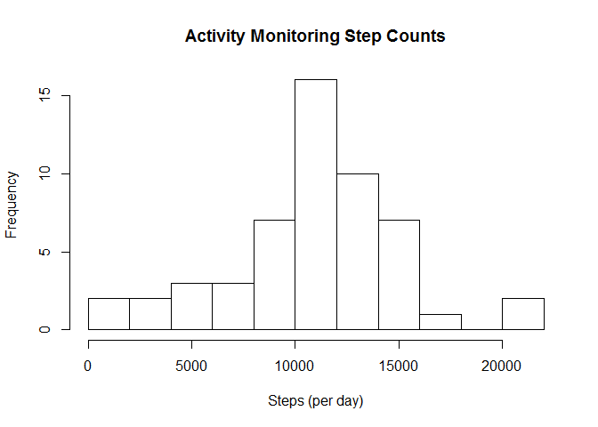

```r
hist(with(activity, tapply(steps, date, sum)),
     main="Activity Monitoring Step Counts", xlab="Steps (per day)", ylab="Frequency",
     breaks = 10)
```

```r
library(xtable)
library(dplyr)
steps_by_date <- activity %>% group_by(date) %>% summarise(mean=mean(steps), median=median(steps, na.rm=TRUE))
print(xtable(steps_by_date), type="html")
```

|  | date | mean | median |
| --- | --- | --- | --- |
| 1 | 2012-10-01 |  |  |
| 2 | 2012-10-02 | 0.44 | 0.00 |
| 3 | 2012-10-03 | 39.42 | 0.00 |
| 4 | 2012-10-04 | 42.07 | 0.00 |
| 5 | 2012-10-05 | 46.16 | 0.00 |
| 6 | 2012-10-06 | 53.54 | 0.00 |
| 7 | 2012-10-07 | 38.25 | 0.00 |
| 8 | 2012-10-08 |  |  |
| 9 | 2012-10-09 | 44.48 | 0.00 |
| 10 | 2012-10-10 | 34.38 | 0.00 |
| 11 | 2012-10-11 | 35.78 | 0.00 |
| 12 | 2012-10-12 | 60.35 | 0.00 |
| 13 | 2012-10-13 | 43.15 | 0.00 |
| 14 | 2012-10-14 | 52.42 | 0.00 |
| 15 | 2012-10-15 | 35.20 | 0.00 |
| 16 | 2012-10-16 | 52.38 | 0.00 |
| 17 | 2012-10-17 | 46.71 | 0.00 |
| 18 | 2012-10-18 | 34.92 | 0.00 |
| 19 | 2012-10-19 | 41.07 | 0.00 |
| 20 | 2012-10-20 | 36.09 | 0.00 |
| 21 | 2012-10-21 | 30.63 | 0.00 |
| 22 | 2012-10-22 | 46.74 | 0.00 |
| 23 | 2012-10-23 | 30.97 | 0.00 |
| 24 | 2012-10-24 | 29.01 | 0.00 |
| 25 | 2012-10-25 | 8.65 | 0.00 |
| 26 | 2012-10-26 | 23.53 | 0.00 |
| 27 | 2012-10-27 | 35.14 | 0.00 |
| 28 | 2012-10-28 | 39.78 | 0.00 |
| 29 | 2012-10-29 | 17.42 | 0.00 |
| 30 | 2012-10-30 | 34.09 | 0.00 |
| 31 | 2012-10-31 | 53.52 | 0.00 |
| 32 | 2012-11-01 |  |  |
| 33 | 2012-11-02 | 36.81 | 0.00 |
| 34 | 2012-11-03 | 36.70 | 0.00 |
| 35 | 2012-11-04 |  |  |
| 36 | 2012-11-05 | 36.25 | 0.00 |
| 37 | 2012-11-06 | 28.94 | 0.00 |
| 38 | 2012-11-07 | 44.73 | 0.00 |
| 39 | 2012-11-08 | 11.18 | 0.00 |
| 40 | 2012-11-09 |  |  |
| 41 | 2012-11-10 |  |  |
| 42 | 2012-11-11 | 43.78 | 0.00 |
| 43 | 2012-11-12 | 37.38 | 0.00 |
| 44 | 2012-11-13 | 25.47 | 0.00 |
| 45 | 2012-11-14 |  |  |
| 46 | 2012-11-15 | 0.14 | 0.00 |
| 47 | 2012-11-16 | 18.89 | 0.00 |
| 48 | 2012-11-17 | 49.79 | 0.00 |
| 49 | 2012-11-18 | 52.47 | 0.00 |
| 50 | 2012-11-19 | 30.70 | 0.00 |
| 51 | 2012-11-20 | 15.53 | 0.00 |
| 52 | 2012-11-21 | 44.40 | 0.00 |
| 53 | 2012-11-22 | 70.93 | 0.00 |
| 54 | 2012-11-23 | 73.59 | 0.00 |
| 55 | 2012-11-24 | 50.27 | 0.00 |
| 56 | 2012-11-25 | 41.09 | 0.00 |
| 57 | 2012-11-26 | 38.76 | 0.00 |
| 58 | 2012-11-27 | 47.38 | 0.00 |
| 59 | 2012-11-28 | 35.36 | 0.00 |
| 60 | 2012-11-29 | 24.47 | 0.00 |
| 61 | 2012-11-30 |  |  |

## What is the average daily activity pattern?

Time series plot (i.e. type = “l”) of the 5-minute interval (x-axis) and the average number of steps taken, averaged across all days (y-axis).

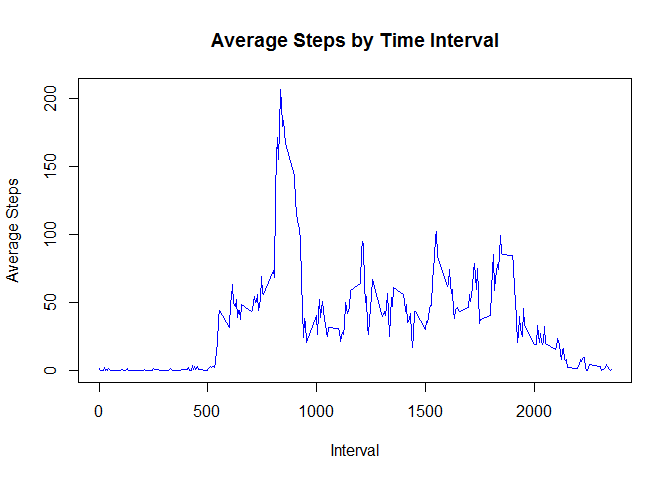

```r
avg_steps_by_interval <- activity %>% group_by(interval) %>% summarise(mean=mean(steps, na.rm=TRUE))
plot(avg_steps_by_interval$interval, avg_steps_by_interval$mean,
     type="l", col="blue", main="Average Steps by Time Interval", xlab="Interval", ylab="Average Steps")
```

```r
with(avg_steps_by_interval, subset(avg_steps_by_interval, mean==max(mean)))
```

```
## # A tibble: 1 × 2
##   interval     mean
##      <int>    <dbl>
## 1      835 206.1698
```

## Imputing missing values

There are 2304 missing values for steps in the activity dataset

```r
summary(activity$steps)
```

```
##    Min. 1st Qu.  Median    Mean 3rd Qu.    Max.    NA's
##    0.00    0.00    0.00   37.38   12.00  806.00    2304
```

Replace the NAs with the median for each day.  
Recall from the table above, all medians are 0.

```r
activity_cleaned <- activity
activity_cleaned[is.na(activity_cleaned)] <- 0
```

```r
steps_by_date_cleaned <- activity_cleaned %>% group_by(date) %>%
        summarise(mean=mean(steps), median=median(steps, na.rm=TRUE))
print(xtable(steps_by_date_cleaned), type="html")
```

|  | date | mean | median |
| --- | --- | --- | --- |
| 1 | 2012-10-01 | 0.00 | 0.00 |
| 2 | 2012-10-02 | 0.44 | 0.00 |
| 3 | 2012-10-03 | 39.42 | 0.00 |
| 4 | 2012-10-04 | 42.07 | 0.00 |
| 5 | 2012-10-05 | 46.16 | 0.00 |
| 6 | 2012-10-06 | 53.54 | 0.00 |
| 7 | 2012-10-07 | 38.25 | 0.00 |
| 8 | 2012-10-08 | 0.00 | 0.00 |
| 9 | 2012-10-09 | 44.48 | 0.00 |
| 10 | 2012-10-10 | 34.38 | 0.00 |
| 11 | 2012-10-11 | 35.78 | 0.00 |
| 12 | 2012-10-12 | 60.35 | 0.00 |
| 13 | 2012-10-13 | 43.15 | 0.00 |
| 14 | 2012-10-14 | 52.42 | 0.00 |
| 15 | 2012-10-15 | 35.20 | 0.00 |
| 16 | 2012-10-16 | 52.38 | 0.00 |
| 17 | 2012-10-17 | 46.71 | 0.00 |
| 18 | 2012-10-18 | 34.92 | 0.00 |
| 19 | 2012-10-19 | 41.07 | 0.00 |
| 20 | 2012-10-20 | 36.09 | 0.00 |
| 21 | 2012-10-21 | 30.63 | 0.00 |
| 22 | 2012-10-22 | 46.74 | 0.00 |
| 23 | 2012-10-23 | 30.97 | 0.00 |
| 24 | 2012-10-24 | 29.01 | 0.00 |
| 25 | 2012-10-25 | 8.65 | 0.00 |
| 26 | 2012-10-26 | 23.53 | 0.00 |
| 27 | 2012-10-27 | 35.14 | 0.00 |
| 28 | 2012-10-28 | 39.78 | 0.00 |
| 29 | 2012-10-29 | 17.42 | 0.00 |
| 30 | 2012-10-30 | 34.09 | 0.00 |
| 31 | 2012-10-31 | 53.52 | 0.00 |
| 32 | 2012-11-01 | 0.00 | 0.00 |
| 33 | 2012-11-02 | 36.81 | 0.00 |
| 34 | 2012-11-03 | 36.70 | 0.00 |
| 35 | 2012-11-04 | 0.00 | 0.00 |
| 36 | 2012-11-05 | 36.25 | 0.00 |
| 37 | 2012-11-06 | 28.94 | 0.00 |
| 38 | 2012-11-07 | 44.73 | 0.00 |
| 39 | 2012-11-08 | 11.18 | 0.00 |
| 40 | 2012-11-09 | 0.00 | 0.00 |
| 41 | 2012-11-10 | 0.00 | 0.00 |
| 42 | 2012-11-11 | 43.78 | 0.00 |
| 43 | 2012-11-12 | 37.38 | 0.00 |
| 44 | 2012-11-13 | 25.47 | 0.00 |
| 45 | 2012-11-14 | 0.00 | 0.00 |
| 46 | 2012-11-15 | 0.14 | 0.00 |
| 47 | 2012-11-16 | 18.89 | 0.00 |
| 48 | 2012-11-17 | 49.79 | 0.00 |
| 49 | 2012-11-18 | 52.47 | 0.00 |
| 50 | 2012-11-19 | 30.70 | 0.00 |
| 51 | 2012-11-20 | 15.53 | 0.00 |
| 52 | 2012-11-21 | 44.40 | 0.00 |
| 53 | 2012-11-22 | 70.93 | 0.00 |
| 54 | 2012-11-23 | 73.59 | 0.00 |
| 55 | 2012-11-24 | 50.27 | 0.00 |
| 56 | 2012-11-25 | 41.09 | 0.00 |
| 57 | 2012-11-26 | 38.76 | 0.00 |
| 58 | 2012-11-27 | 47.38 | 0.00 |
| 59 | 2012-11-28 | 35.36 | 0.00 |
| 60 | 2012-11-29 | 24.47 | 0.00 |
| 61 | 2012-11-30 | 0.00 | 0.00 |

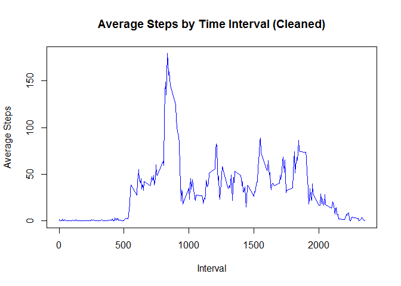

```r
avg_steps_by_interval_cleaned <- activity_cleaned %>% group_by(interval) %>%
        summarise(mean=mean(steps, na.rm=TRUE))
plot(avg_steps_by_interval_cleaned$interval, avg_steps_by_interval_cleaned$mean,
     type="l", col="blue", main="Average Steps by Time Interval (Cleaned)", xlab="Interval", ylab="Average Steps")
```

## Are there differences in activity patterns between weekdays and weekends?

Prepare the weekday and weekend data sets

```r
activity_cleaned$date <- as.Date(activity_cleaned$date)
activity_cleaned$weekday<-as.numeric(format(as.Date(activity_cleaned$date),"%w"))
activity_cleaned$weekday<-factor(activity_cleaned$weekday <= 5,
        levels=c("TRUE","FALSE"), labels=c("weekday","weekend"))

interval_by_factor <- activity_cleaned %>% group_by(interval, weekday) %>%
        summarise(mean=mean(steps, na.rm=TRUE))
```

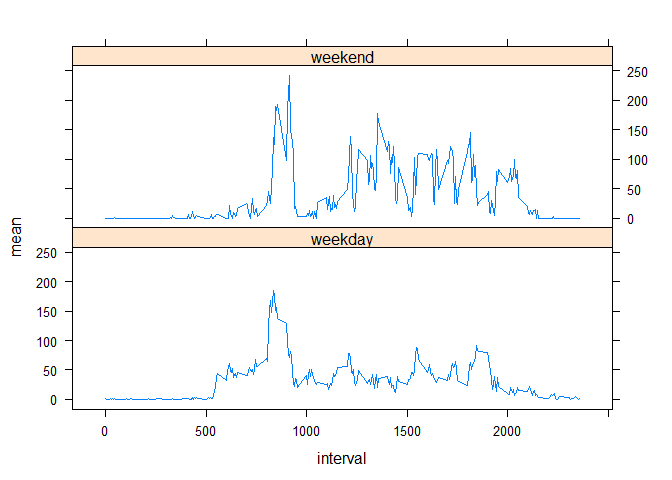

```r
library(lattice)
xyplot(mean ~ interval | weekday, data=interval_by_factor, layout=c(1,2), type="l")
```